# Reporte de Escrituras

ESCRITURAS DE COMPRAVENTA REGISTRADAS EN LA PROVINCIA DE SANTA FE

Datos actualizados al 22 de agosto de 2025

Último dato disponible: 2025.M5

## Alcance

El reporte presenta información suministrada por las dos circunscripciones del Colegio de Escribanos de la provincia de Santa Fe. La primera, con sede en la ciudad de Santa Fe, abarca el centro-norte provincial; y la segunda, con sede en la ciudad Rosario, comprende los departamentos del sur. Las estadísticas expuestas refieren a las escrituras de compraventa<sup>1</sup> registradas mensualmente por los profesionales matriculados.

## Objetivo

Complementar el análisis de la actividad económica y dar a conocer en forma periódica la evolución de las ventas de inmuebles dentro del territorio de la provincia de Santa Fe.

## >> Principales resultados | Datos sin filtrar

- Durante **2024**, se registraron un total de **26.021** escrituras por compraventa en la provincia de Santa Fe.
- En lo que va de **2025**, entre enero y mayo, se han otorgado **13.295** escrituras. Esto representa un alza de 75,91% respecto al mismo período del año precedente.
- Por su parte, en el mes de **mayo** del presente año, las escrituras registradas en sede *Santa Fe* fueron **1.297**, mientras que las de la sede *Rosario* fueron **1.473**.
- En cuanto al total de escrituras otorgadas en mayo a nivel provincial, considerando las dos circunscripciones, se alcanzaron los **2.770** registros. En este sentido, la serie señala una variación mensual de **-4,94%**. Por su parte, en términos interanuales, la cantidad total de escrituras presenta una variación de **25,23%**.

> <sup>1</sup> En forma taxativa incluyen actos de: venta, venta con reserva de usufructo, venta nuda propiedad, venta de partes indivisas, venta por tracto abreviado, venta FONAVI, venta e hipoteca FONAVI, venta e hipoteca - P. Federal, venta (nuda propiedad y usufructo), venta con toma a cargo embargo, venta ley 12.953, venta ley 24.374.

## CANTIDAD DE ESCRITURAS REGISTRADAS | DATOS SIN FILTRAR

### Tabla 1 | Escrituras registradas en cada sede y en el agregado provincial. Datos brutos sin filtrar.

[output not shown]

#### Fuente: CES-BCSF en base a datos suministrados por el Colegio de Escribanos de la provincia de Santa Fe.

### Gráfico 1 | Escrituras de compraventa registradas en cada sede. Datos brutos sin filtrar.

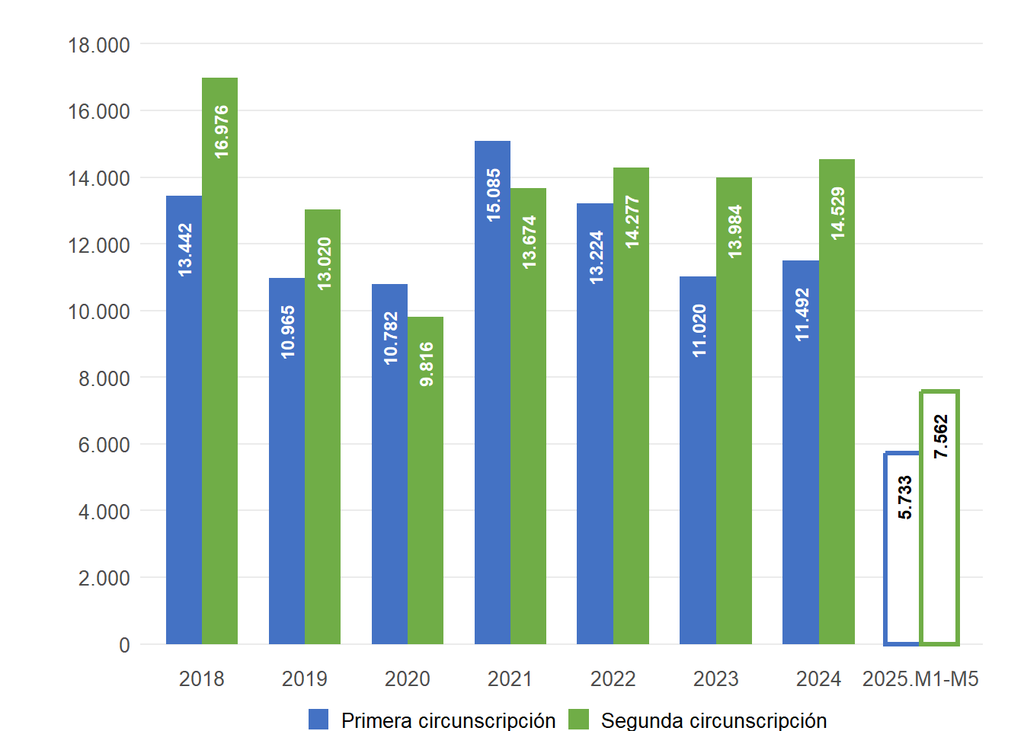

#### Fuente: CES-BCSF en base a datos suministrados por el Colegio de Escribanos de la provincia de Santa Fe.

## EVOLUCION DE LAS ESCRITURAS REGISTRADAS Y CICLO ECONOMICO

En esta sección se presenta la evolución de las escrituras luego de filtrar los datos brutos por estacionalidad. Además, se exponen en forma superpuesta las recesiones económicas datadas para la provincia de Santa Fe, en función al índice de actividad económica coincidente elaborado por CES-BCSF. Para profundizar en aspectos técnicos y obtener más información, visite nuestra sección [web de gráficas interactivas](https://www.bcsf.com.ar/ces/graficas-interactivas.php) en la sección 3.4.

### Gráfico 2 | Escrituras registradas en la provincia de Santa Fe. Datos brutos y desestacionalizados.

[interactive chart not shown]

#### Referencia: las zonas grises señalan las recesiones económicas datadas por CES-BCSF.

#### Fuente: CES-BCSF en base a datos suministrados por el Colegio de Escribanos de la provincia de Santa Fe.

### Gráfico 3 | Escrituras registradas en cada circunscripción. Series filtradas por estacionalidad.

[interactive chart not shown]

#### Referencia: las zonas grises señalan las recesiones económicas datadas por CES-BCSF.

#### Fuente: CES-BCSF en base a datos suministrados por el Colegio de Escribanos de la provincia de Santa Fe.